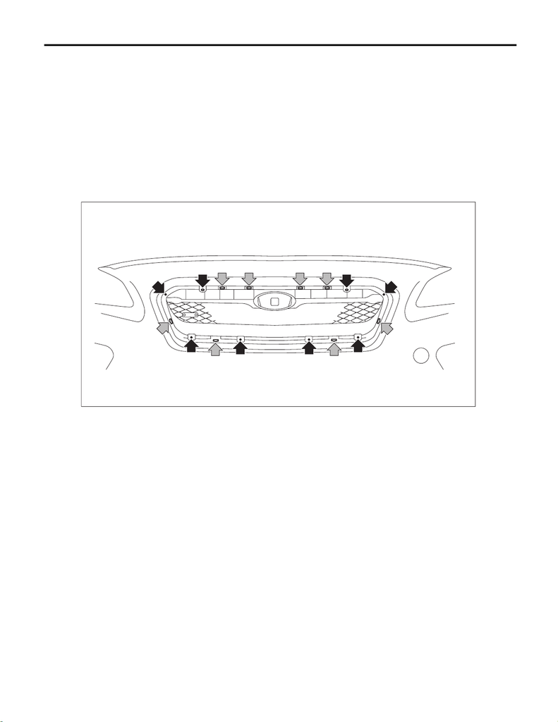

7. Front Grille

A: REMOVAL

1) Disconnect the ground cable from battery. <Ref. to NT-5, BATTERY, NOTE, Note.>

NOTE:

For models other than STI model, disconnect the ground terminal from battery sensor.

2) Remove the bumper face - front. <Ref. to EI-30, REMOVAL, Front Bumper.>

3) Remove the front grille assembly.

(1) Remove the screws on the back side.

(2) Release the claws, and remove the front grille assembly.

CAUTION:

Remove the front grille assembly horizontally. Otherwise, the bumper may be damaged.

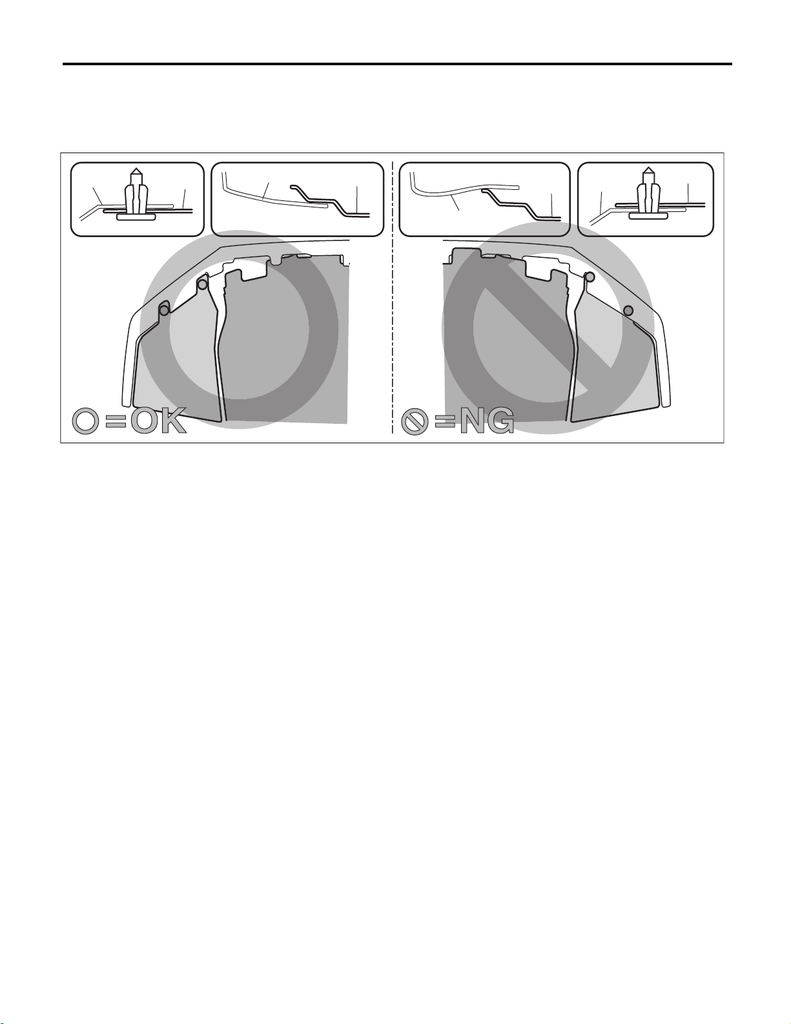

B: INSTALLATION

CAUTION:

front end of the mud guard (c) comes outside the bumper face - front (a).

section may be broken or the clearance between fender panel and bumper face may not be uniform.

1) Install the front grille assembly.

CAUTION:

When replacing the bumper, be sure to install the spacer grille front to the bumper.

2) Install the bumper face - front. <Ref. to EI-34, INSTALLATION, Front Bumper.>

3) Connect the battery ground terminal. <Ref. to NT-5, BATTERY, NOTE, Note.>

NOTE:

For models other than STI model, connect the ground terminal to battery sensor.

Fog Light Assembly.>